# Proyecto

### Diego Fernando Vargas Poveda y William Camilo López

> El objetivo es aplicar el proceso KDD para un modelo de minería de datos, utilizando una base de datos recopilados en el mundo real. Para ello los estudiantes deben elegir un data set que provenga de la sección recursos, de los cuales NO se podrá elegir data sets que estén en el top de los más populares y estén con el debido permiso de confidencialidad, en el cuál deben desarrollar los siguientes puntos: Entrega 1: + Breve explicación de la elección del dataset: características, número de atributos y variables, área al que pertenecen los datos. + Posibles escenarios de solución en minería de datos ¿Es un problema de aprendizaje supervisado o no supervisado? ¿Es clasificación o regresión? ¿Es clustering o reducción de dimensionalidad? Justifique su elección. + Haga un análisis exploratorio de datos y haga una pre-selección de variables basado en este análisis. Utilice al menos una visualización de datos por integrante de grupo. Saque sus primeras conclusiones de los datos.

#### Breve explicación del dataset:

La base escogida se denomina Facebook Comment Volume Dataset, disponible en el siguiente [link](https://archive.ics.uci.edu/ml/datasets/Facebook+Comment+Volume+Dataset):

Ahora bien, Facebook es la principal red social que existe en el mundo. Una red de vínculos virtuales, cuyo principal objetivo es dar un soporte para producir y compartir contenidos. Los comentarios insertados permiten incluir comentarios en publicaciones públicas (de una página o una persona en Facebook) en el contenido de un sitio o una página web con gran facilidad. Solo pueden insertarse comentarios públicos de perfiles y páginas de Facebook.

**Características de la base de datos**

La cantidad de datos que se cargan en los servicios de redes sociales está aumentando día a día. Por lo tanto, es posible estudiar los comportamientos dinámicos de los usuarios hacia estos servicios. Con esta base de datos se busca modelar patrones de comentarios del usuario, sobre las publicaciones en las páginas de Facebook y predecir cuántos comentarios se espera que reciba una publicación en la próxima hora.

**Número de atributos**

La base de datos tiene 40949 observaciones.

**Variables**

Esta base de datos tiene 54 variables incluyendo la variable de interés (No. de comentarios que puede recibir un post), dentro de las variables a destacar se tiene:

- No. de comentarios
- Publicación promocionada (0,1)
- Día de la publicación
- Horas de medición (24-48-72)
- No de visitias a la página que tiene la publicación
- Clasificación de la página que hace la publicación
- Características técnicas de la página
- Tamaño del post

**Área que pertenece los datos**

Los datos pertenecen a redes sociales.

**Posibles escenarios de solución**

- Aprendizaje supervisado
- Tipo de análisis: Regresión

**Análisis exploratorio**

```python
import pandas as pd
import os

os.chdir("/Users/mac/Documents/Documentos Diego/Universidad/Mineria")

df = pd.read_csv('Features_Variant.csv',delimiter=";")
```

```python
df
```

|  | Popularidad | Visitas | Interes | Categoria del lugar | Feature1 | Feature2 | Feature3 | Feature4 | Feature5 | Feature6 | ... | Sabado Publicacion | Domingo Publicacion | Lunes | Martes | Miercoles | Jueves | Viernes | Sabado | Domingo | No de comentarios |
| --- | --- | --- | --- | --- | --- | --- | --- | --- | --- | --- | --- | --- | --- | --- | --- | --- | --- | --- | --- | --- | --- |
| 0 | 634995 | 0 | 463 | 1 | 0.0 | 806.0 | 11.291.044.776.119.400 | 1.0 | 7.049.513.846.124.160 | 0.0 | ... | 0 | 0 | 0 | 0 | 0 | 0 | 0 | 0 | 1 | 0 |
| 1 | 634995 | 0 | 463 | 1 | 0.0 | 806.0 | 11.291.044.776.119.400 | 1.0 | 7.049.513.846.124.160 | 0.0 | ... | 0 | 0 | 0 | 0 | 0 | 0 | 0 | 1 | 0 | 0 |
| 2 | 634995 | 0 | 463 | 1 | 0.0 | 806.0 | 11.291.044.776.119.400 | 1.0 | 7.049.513.846.124.160 | 0.0 | ... | 1 | 0 | 0 | 0 | 0 | 0 | 0 | 0 | 1 | 0 |
| 3 | 634995 | 0 | 463 | 1 | 0.0 | 806.0 | 11.291.044.776.119.400 | 1.0 | 7.049.513.846.124.160 | 0.0 | ... | 1 | 0 | 0 | 1 | 0 | 0 | 0 | 0 | 0 | 0 |
| 4 | 634995 | 0 | 463 | 1 | 0.0 | 806.0 | 11.291.044.776.119.400 | 1.0 | 7.049.513.846.124.160 | 0.0 | ... | 0 | 0 | 0 | 0 | 0 | 1 | 0 | 0 | 0 | 0 |
| ... | ... | ... | ... | ... | ... | ... | ... | ... | ... | ... | ... | ... | ... | ... | ... | ... | ... | ... | ... | ... | ... |
| 40944 | 7170111 | 70 | 497000 | 9 | 0.0 | 1881.0 | 497.2 | 269.0 | 50.231.838.509.057.100 | 0.0 | ... | 0 | 0 | 0 | 0 | 0 | 0 | 0 | 1 | 0 | 1 |
| 40945 | 7170111 | 70 | 497000 | 9 | 0.0 | 1881.0 | 497.2 | 269.0 | 50.231.838.509.057.100 | 0.0 | ... | 0 | 0 | 0 | 0 | 0 | 0 | 0 | 1 | 0 | 2 |
| 40946 | 7170111 | 70 | 497000 | 9 | 0.0 | 1881.0 | 497.2 | 269.0 | 50.231.838.509.057.100 | 0.0 | ... | 0 | 0 | 0 | 0 | 0 | 0 | 1 | 0 | 0 | 72 |
| 40947 | 7170111 | 70 | 497000 | 9 | 0.0 | 1881.0 | 497.2 | 269.0 | 50.231.838.509.057.100 | 0.0 | ... | 0 | 0 | 0 | 0 | 0 | 0 | 0 | 1 | 0 | 28 |
| 40948 | 7170111 | 70 | 497000 | 9 | 0.0 | 1881.0 | 497.2 | 269.0 | 50.231.838.509.057.100 | 0.0 | ... | 0 | 0 | 0 | 0 | 0 | 0 | 0 | 1 | 0 | 11 |

40949 rows × 54 columns

```python
dias = df[['Lunes Publicacion','Martes Publicacion','Miercoles Publicacion','Jueves Publicacion','Viernes Publicacion','Sabado Publicacion','Domingo Publicacion']]
```

```python
tab4=dias.sum().rename_axis('label').reset_index(name='counts')
```

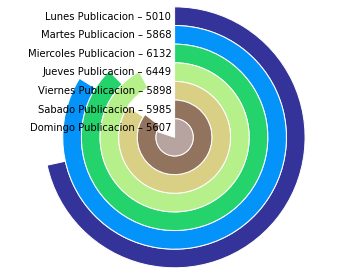

```python
import matplotlib.pyplot as plt
from matplotlib import cm
from math import log10


labels = tab4['label']
data = tab4['counts']
#number of data points
n = len(data)
#find max value for full ring
k = 10 ** int(log10(max(data)))
m = k * (1 + max(data) // k)


#radius of donut chart
r = 1.5
#calculate width of each ring
w = r / n


#create colors along a chosen colormap
colors = [cm.terrain(i / n) for i in range(n)]

#create figure, axis
fig, ax = plt.subplots()
ax.axis("equal")

#create rings of donut chart
for i in range(n):
    #hide labels in segments with textprops: alpha = 0 - transparent, alpha = 1 - visible
    innerring, _ = ax.pie([m - data[i],
                           data[i]],
                          radius = r - i * w,
                          startangle = 90,
                          labels = ["", labels[i]],
                          labeldistance = 1 - 1 / (1.5 * (n - i)),
                          textprops = {"alpha": 0},
                          colors = ["white", colors[i]])
    plt.setp(innerring,
             width = w,
             edgecolor = "white")
    radius = r - i * w
    plt.text(0, radius - w / 2, f'{labels[i]} – {data[i]} ', ha='right', va='center')

#plt.legend()
plt.show()
```

```python
df['No de comentarios'].describe()
```

```
count    40949.000000
mean         7.322889
std         35.494550
min          0.000000
25%          0.000000
50%          0.000000
75%          3.000000
max       1305.000000
Name: No de comentarios, dtype: float64
```

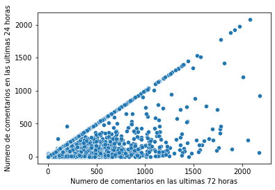

```python
import pandas as pd
import numpy as np
import seaborn as sns
import matplotlib as plt
import matplotlib.pyplot as plt


sns.scatterplot(data=df,  x="Numero de comentarios en las ultimas 72 horas", y="Numero de comentarios en las ultimas 24 horas")
```

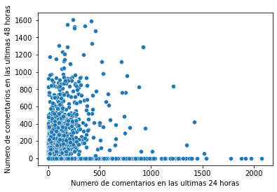

```python
sns.scatterplot(data=df,  x="Numero de comentarios en las ultimas 24 horas", y="Numero de comentarios en las ultimas 48 horas")
```

[figure not shown]